# Automated model development

```r
library(tidyverse)
library(leaps)
library(CodeClanData)
```

```r
insurance
```

| age | sex | bmi | children | smoker | region | charges |
| --- | --- | --- | --- | --- | --- | --- |
| 19 | female | 27.900 | 0 | yes | southwest | 16884.924 |
| 18 | male | 33.770 | 1 | no | southeast | 1725.552 |
| 28 | male | 33.000 | 3 | no | southeast | 4449.462 |
| 33 | male | 22.705 | 0 | no | northwest | 21984.471 |
| 32 | male | 28.880 | 0 | no | northwest | 3866.855 |
| 31 | female | 25.740 | 0 | no | southeast | 3756.622 |
| 46 | female | 33.440 | 1 | no | southeast | 8240.590 |
| 37 | female | 27.740 | 3 | no | northwest | 7281.506 |
| 37 | male | 29.830 | 2 | no | northeast | 6406.411 |
| 60 | female | 25.840 | 0 | no | northwest | 28923.137 |

[output cut: 990 more lines]

```r
regsubsets_forwards <- regsubsets(charges ~ .,
                                  data = insurance,
                                  nvmax = 8,
                                  method = "forward")
```

```r
sum_regsubsets_forwards <- summary(regsubsets_forwards)

sum_regsubsets_forwards
```

```
Subset selection object
Call: regsubsets.formula(charges ~ ., data = insurance, nvmax = 8,
    method = "forward")
8 Variables  (and intercept)
                Forced in Forced out
age                 FALSE      FALSE
sexmale             FALSE      FALSE
bmi                 FALSE      FALSE
children            FALSE      FALSE
smokeryes           FALSE      FALSE
regionnorthwest     FALSE      FALSE
regionsoutheast     FALSE      FALSE
regionsouthwest     FALSE      FALSE
1 subsets of each size up to 8
Selection Algorithm: forward
         age sexmale bmi children smokeryes regionnorthwest regionsoutheast regionsouthwest
1  ( 1 ) " " " "     " " " "      "*"       " "             " "             " "
2  ( 1 ) "*" " "     " " " "      "*"       " "             " "             " "
3  ( 1 ) "*" " "     "*" " "      "*"       " "             " "             " "
4  ( 1 ) "*" " "     "*" "*"      "*"       " "             " "             " "
5  ( 1 ) "*" " "     "*" "*"      "*"       " "             "*"             " "
6  ( 1 ) "*" " "     "*" "*"      "*"       " "             "*"             "*"
7  ( 1 ) "*" " "     "*" "*"      "*"       "*"             "*"             "*"
8  ( 1 ) "*" "*"     "*" "*"      "*"       "*"             "*"             "*"
```

in the above results reading along the lines each star indecaes which perditers to include ie 1 perditer should include smokeryes, 3 perditers age, bmi, smokeryes.

```r
sum_regsubsets_forwards$which
```

```
  (Intercept)   age sexmale   bmi children smokeryes regionnorthwest regionsoutheast regionsouthwest
1        TRUE FALSE   FALSE FALSE    FALSE      TRUE           FALSE           FALSE           FALSE
2        TRUE  TRUE   FALSE FALSE    FALSE      TRUE           FALSE           FALSE           FALSE
3        TRUE  TRUE   FALSE  TRUE    FALSE      TRUE           FALSE           FALSE           FALSE
4        TRUE  TRUE   FALSE  TRUE     TRUE      TRUE           FALSE           FALSE           FALSE
5        TRUE  TRUE   FALSE  TRUE     TRUE      TRUE           FALSE            TRUE           FALSE
6        TRUE  TRUE   FALSE  TRUE     TRUE      TRUE           FALSE            TRUE            TRUE
7        TRUE  TRUE   FALSE  TRUE     TRUE      TRUE            TRUE            TRUE            TRUE
8        TRUE  TRUE    TRUE  TRUE     TRUE      TRUE            TRUE            TRUE            TRUE
```

```r
sum_regsubsets_forwards$which[3,]
```

```
    (Intercept)             age         sexmale             bmi        children       smokeryes
           TRUE            TRUE           FALSE            TRUE           FALSE            TRUE
regionnorthwest regionsoutheast regionsouthwest
          FALSE           FALSE           FALSE
```

```r
plot(regsubsets_forwards, scale = "adjr2")
```

[output not shown]

Reading a long the rows each black boxs is included

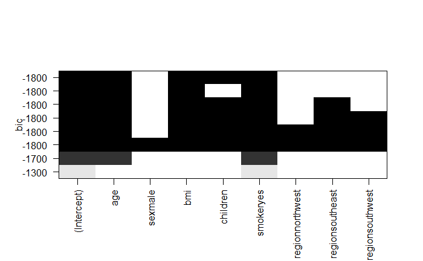

```r
plot(regsubsets_forwards, scale = "bic")
```

null model = lm(charges ~1) wellfit model = lm(charges ~ age + bmi = children + smoker)

BIC(wellfit_model) - BIC(null_model)

```r
null_model = lm(charges ~ 1, data = insurance)
wellfit_model = lm(charges ~ age + bmi + children + smoker,
                   data = insurance)
overfit_model = lm(charges ~ ., data = insurance)

BIC(wellfit_model) - BIC(null_model)
```

```
[1] -1824.432
```

```r
BIC(overfit_model) - BIC(null_model)
```

```
[1] -1802.166
```

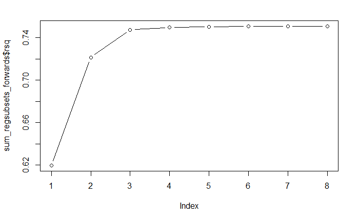

```r
plot(sum_regsubsets_forwards$rsq, type = "b")
```

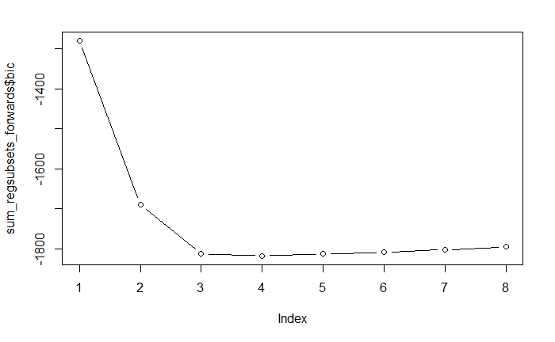

```r
plot(sum_regsubsets_forwards$bic, type = "b")
```

BIC from 5 onwards it rises back up as it is overfitted as it is too complex.

These show 3 and 4 have very little diffrence between them and are the best to use, we when with 3 it had the least number of perditers.

Task - 10 mins Re-run the analyses above using the backward selection and exhaustive search variable selection methods [Hint - look at the regsubsets() docs to see how to do this] Compare the tables (or plots, whichever you find easier) showing which predictors are included for forward selection, backward selection and exhaustive search. Do you find any differences? Use adjusted R-squared as your measure of fit.

```r
regsubsets_backwards <- regsubsets(charges ~ .,
                                  data = insurance,
                                  nvmax = 8,
                                  method = "backward")

plot(regsubsets_backwards, scale = "adjr2")
```

[output not shown]

```r
regsubsets_muti <- regsubsets(charges ~ .,
                                  data = insurance,
                                  nvmax = 8,
                                  method = c("backward", "forward"))

plot(regsubsets_backwards, scale = "adjr2")
```

[output not shown]

# Human intervention is needed…

Finally, understand that the models returned by the variable selection methods and chosen by us on the basis of AIC, BIC etc. have not been tested for statistical significance. We should perform these tests, and also check that any model we select makes sense in terms of the context of the analysis we are undertaking.

Let’s check the specification of the 6 -predictor model!

```r
summary(regsubsets_muti)$which[6,]
```

```
    (Intercept)             age         sexmale             bmi        children       smokeryes
           TRUE            TRUE           FALSE            TRUE            TRUE            TRUE
regionnorthwest regionsoutheast regionsouthwest
          FALSE            TRUE            TRUE
```

```r
mod_without_region <- lm(charges ~ age + bmi + children + smoker,
                         data = insurance)
summary(mod_without_region)
```

```
Call:
lm(formula = charges ~ age + bmi + children + smoker, data = insurance)

Residuals:
     Min       1Q   Median       3Q      Max
-11897.9  -2920.8   -986.6   1392.2  29509.6

Coefficients:
             Estimate Std. Error t value Pr(>|t|)
(Intercept) -12102.77     941.98 -12.848  < 2e-16 ***
age            257.85      11.90  21.675  < 2e-16 ***
bmi            321.85      27.38  11.756  < 2e-16 ***
children       473.50     137.79   3.436 0.000608 ***
smokeryes    23811.40     411.22  57.904  < 2e-16 ***
---
Signif. codes:  0 ‘***’ 0.001 ‘**’ 0.01 ‘*’ 0.05 ‘.’ 0.1 ‘ ’ 1

Residual standard error: 6068 on 1333 degrees of freedom
Multiple R-squared:  0.7497,    Adjusted R-squared:  0.7489
F-statistic: 998.1 on 4 and 1333 DF,  p-value: < 2.2e-16
```

```r
mod_with_region <- lm(charges ~ age + bmi +
                        children + smoker + region,
                      data = insurance)
summary(mod_with_region)
```

```
Call:
lm(formula = charges ~ age + bmi + children + smoker + region,
    data = insurance)

Residuals:
     Min       1Q   Median       3Q      Max
-11367.2  -2835.4   -979.7   1361.9  29935.5

Coefficients:
                 Estimate Std. Error t value Pr(>|t|)
(Intercept)     -11990.27     978.76 -12.250  < 2e-16 ***
age                256.97      11.89  21.610  < 2e-16 ***
bmi                338.66      28.56  11.858  < 2e-16 ***
children           474.57     137.74   3.445 0.000588 ***
smokeryes        23836.30     411.86  57.875  < 2e-16 ***
regionnorthwest   -352.18     476.12  -0.740 0.459618
regionsoutheast  -1034.36     478.54  -2.162 0.030834 *
regionsouthwest   -959.37     477.78  -2.008 0.044846 *
---
Signif. codes:  0 ‘***’ 0.001 ‘**’ 0.01 ‘*’ 0.05 ‘.’ 0.1 ‘ ’ 1

Residual standard error: 6060 on 1330 degrees of freedom
Multiple R-squared:  0.7509,    Adjusted R-squared:  0.7496
F-statistic: 572.7 on 7 and 1330 DF,  p-value: < 2.2e-16
```

```r
anova(mod_with_region, mod_without_region)
```

```
Analysis of Variance Table

Model 1: charges ~ age + bmi + children + smoker + region
Model 2: charges ~ age + bmi + children + smoker
  Res.Df        RSS Df  Sum of Sq      F  Pr(>F)
1   1330 4.8845e+10
2   1333 4.9078e+10 -3 -233200844 2.1166 0.09631 .
---
Signif. codes:  0 ‘***’ 0.001 ‘**’ 0.01 ‘*’ 0.05 ‘.’ 0.1 ‘ ’ 1
```

The model with region is not significantly better than the model without, so we should discard region. Let’s check the diagnostics of mod_without_region

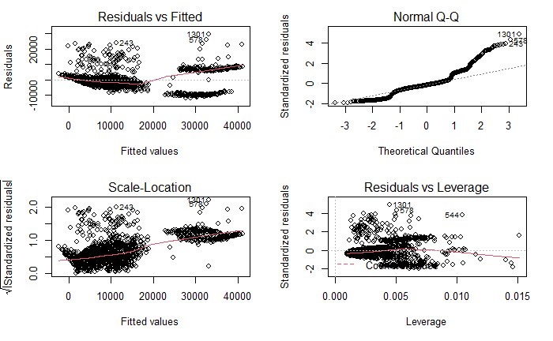

```r
par(mfrow = c(2, 2))
plot(mod_without_region)
```

Hmm, the diagnostic plots don’t look very promising for this model, the residuals are clearly not normal, and there is evidence of heteroscedasticity. Some variable transformations may be necessary (in which case, we would need to start the variable selection process again after performing the transformations).

Task - 5 mins

Go ahead and extract the 3 -predictor model, and then check its significance and the diagnostic plots.

```r
summary(regsubsets_muti)$which[3,]
```

```
    (Intercept)             age         sexmale             bmi        children       smokeryes
           TRUE            TRUE           FALSE            TRUE           FALSE            TRUE
regionnorthwest regionsoutheast regionsouthwest
          FALSE           FALSE           FALSE
```

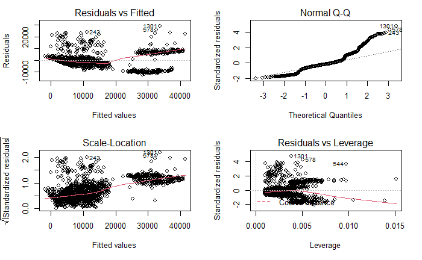

```r
mod_with_3 <- lm(charges ~ age + bmi +
                           smoker,
                         data = insurance)

par(mfrow = c(2, 2))
plot(mod_with_3)
```

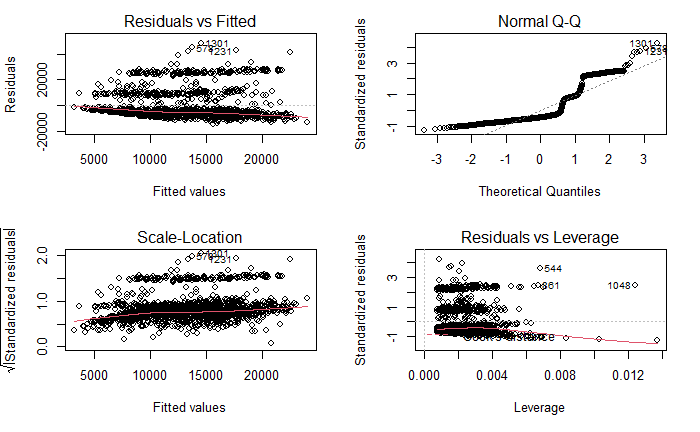

```r
mod_with_2 <- lm(charges ~ age + bmi,
                         data = insurance)

par(mfrow = c(2, 2))
plot(mod_with_2)
```